# Project 1

## Load the data

Load the data and show the first 10 rows.

```r
df <- read.csv('creditBalance.csv', header = TRUE)
head(df, 10)
```

```
##     Income Limit Rating Cards Age Education Gender Student Married Balance
## 1   14.891  3606    283     2  34        11   Male      No     Yes     333
## 2  106.025  6645    483     3  82        15 Female     Yes     Yes     903
## 3  104.593  7075    514     4  71        11   Male      No      No     580
## 4  148.924  9504    681     3  36        11 Female      No      No     964
## 5   55.882  4897    357     2  68        16   Male      No     Yes     331
## 6   80.180  8047    569     4  77        10   Male      No      No    1151
## 7   20.996  3388    259     2  37        12 Female      No      No     203
## 8   71.408  7114    512     2  87         9   Male      No      No     872
## 9   15.125  3300    266     5  66        13 Female      No      No     279
## 10  71.061  6819    491     3  41        19 Female     Yes     Yes    1350
```

## Summarize the data

Summarize the data with ‘summary’ function. There are 10 columns and 310 rows in the dataset with no null value. Three of the columns are characteristic (i.e., Gender, Student, Married) and the rest are numeric. And it seems like there is no redundant columns or numeric columns that should have been traeted as characteristic (assuming ‘Education’ is some sort of score). A summary is shown as below.

```r
summary(df)
```

```
##      Income           Limit           Rating          Cards
##  Min.   : 10.35   Min.   : 1160   Min.   :126.0   Min.   :1.000
##  1st Qu.: 23.15   1st Qu.: 3976   1st Qu.:304.0   1st Qu.:2.000
##  Median : 37.14   Median : 5147   Median :380.0   Median :3.000
##  Mean   : 49.98   Mean   : 5485   Mean   :405.1   Mean   :2.997
##  3rd Qu.: 63.74   3rd Qu.: 6453   3rd Qu.:469.0   3rd Qu.:4.000
##  Max.   :186.63   Max.   :13913   Max.   :982.0   Max.   :9.000
##       Age          Education        Gender            Student
##  Min.   :23.00   Min.   : 5.00   Length:310         Length:310
##  1st Qu.:42.00   1st Qu.:11.00   Class :character   Class :character
##  Median :55.50   Median :14.00   Mode  :character   Mode  :character
##  Mean   :55.61   Mean   :13.43
##  3rd Qu.:69.00   3rd Qu.:16.00
##  Max.   :98.00   Max.   :20.00
##    Married             Balance
##  Length:310         Min.   :   5.0
##  Class :character   1st Qu.: 338.0
##  Mode  :character   Median : 637.5
##                     Mean   : 671.0
##                     3rd Qu.: 960.8
##                     Max.   :1999.0
```

```r
dim(df)
```

```
## [1] 310  10
```

```r
sum(is.na(df))
```

```
## [1] 0
```

A faceted histogram for all the variables that are truly quantitative (i.e., Income, Limit, Rating, Cards, Age, Education, Balance).

```r
library(tidyverse)
```

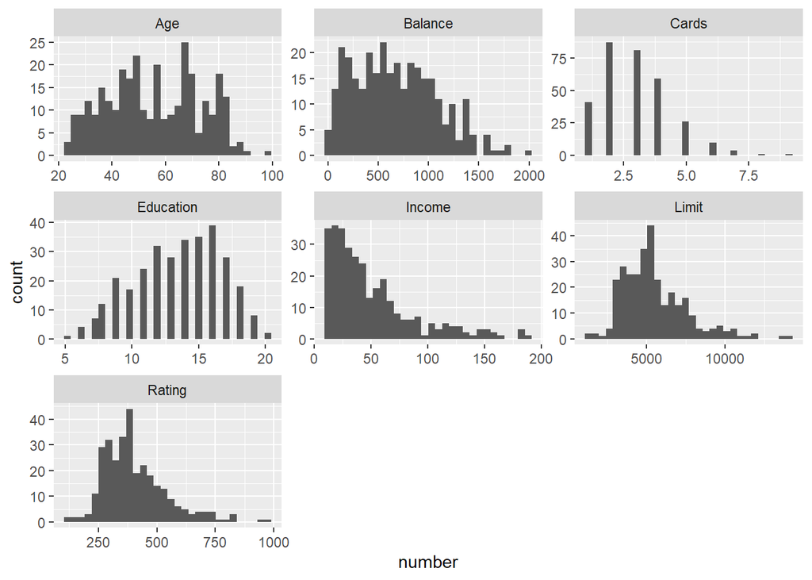

```r
n <- gather(df %>% select(.,Income, Limit, Rating, Cards, Age, Education, Balance), key = 'character', value = 'number')
ggplot(data = n, mapping=aes(x = number)) +
  geom_histogram() +
  facet_wrap(~character, scales = 'free')
```

A facet bar chart for characteristic columns. We can say the data is balanced in terms of ‘Gender’ and unbalance in terms of ‘Married’ (with more married samples). But since ‘Age’ is pretty wide spread, it seems fair that only a small portion of the samples are ‘Student’.

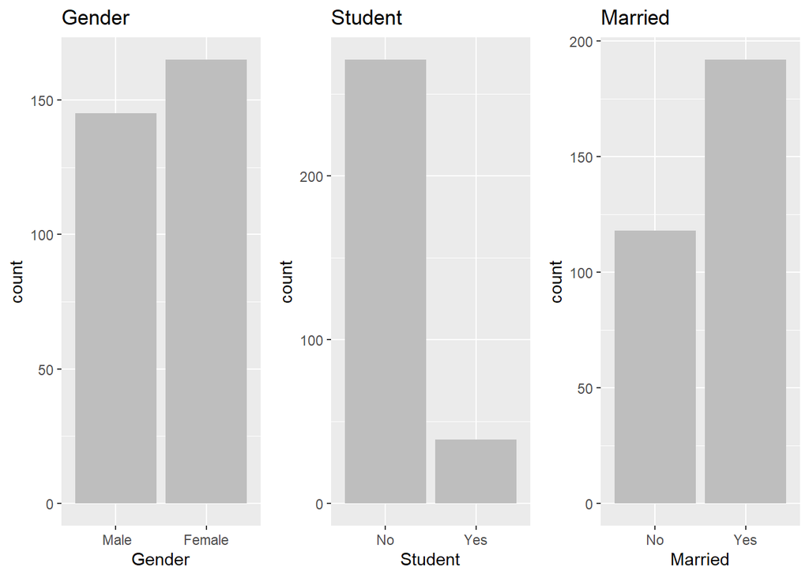

```r
library(ggpubr)

b <- df %>% select(Gender)
p1 <- ggplot(data = b, mapping=aes(x=Gender)) +
  geom_bar(fill = "gray") +
  ggtitle("Gender")

b <- df %>% select(Student)
p2 <- ggplot(data = b, mapping=aes(x=Student)) +
   geom_bar(fill = "gray") +
  ggtitle("Student")

b <- df %>% select(Married)
p3 <- ggplot(data = b, mapping=aes(x=Married)) +
  geom_bar(fill = "gray") +
  ggtitle("Married")

ggarrange(p1, p2, p3, ncol = 3, nrow = 1)
```

Assuming ‘Balance’ is our response variable, create side-by-side boxplots for ‘Balance’ v.s ‘Gender’, ‘Balance’ v.s ‘Student’, and ‘Balance’ v.s ‘Married’.

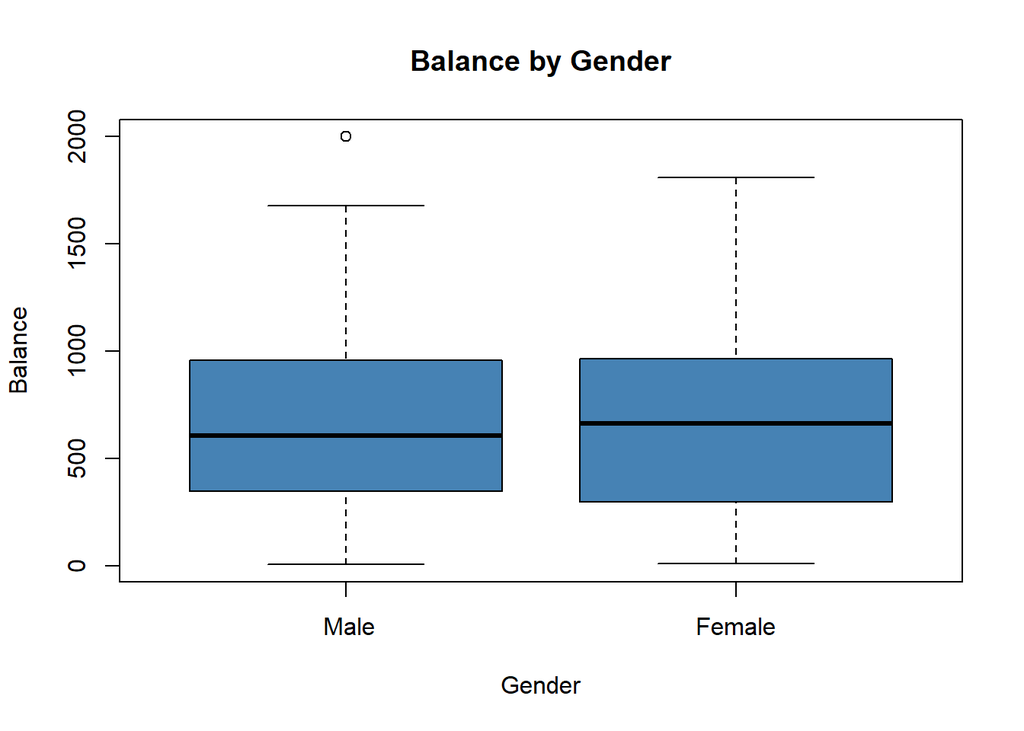

```r
boxplot(df$Balance ~ df$Gender,
        col='steelblue',
        main='Balance by Gender',
        xlab='Gender',
        ylab='Balance')
```

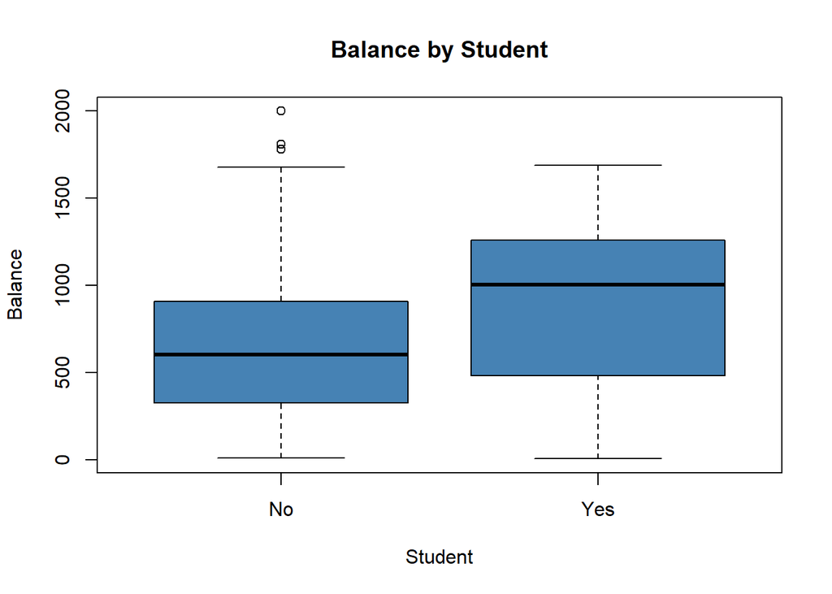

```r
boxplot(df$Balance ~ df$Student,
        col='steelblue',
        main='Balance by Student',
        xlab='Student',
        ylab='Balance')
```

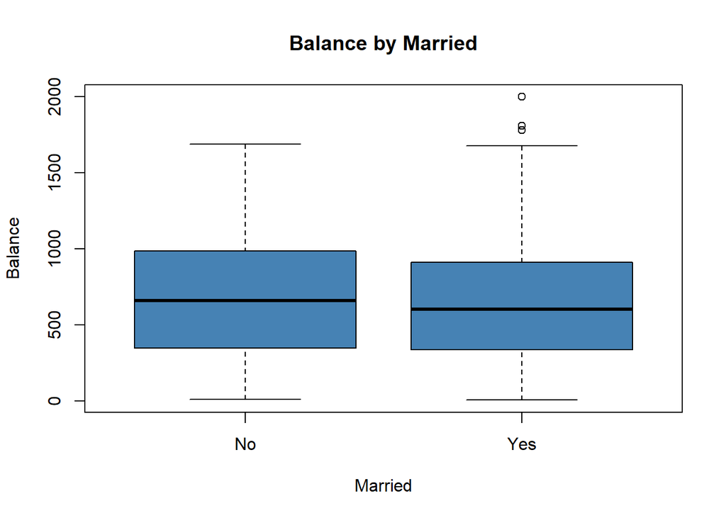

```r
boxplot(df$Balance ~ df$Married,
        col='steelblue',
        main='Balance by Married',
        xlab='Married',
        ylab='Balance')
```

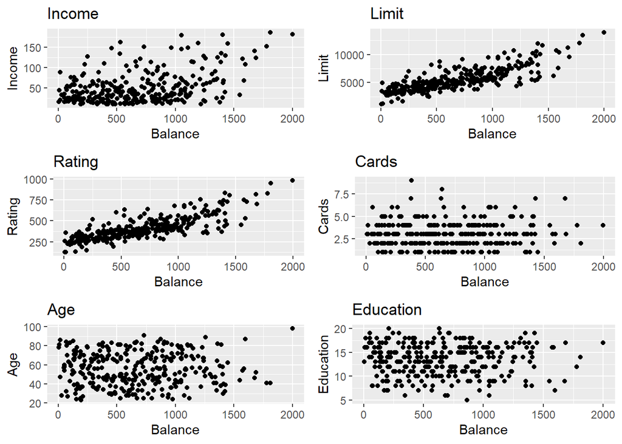

```r
a <- df %>% select(Income, Balance)
p1 <- ggplot(data = a, mapping=aes(y=Income, x = Balance)) +
  geom_point() +
  ggtitle("Income")

b <- df %>% select(Limit, Balance)
p2 <- ggplot(data = b, mapping=aes(y=Limit, x = Balance)) +
   geom_point() +
  ggtitle("Limit")

c <- df %>% select(Rating, Balance)
p3 <- ggplot(data = c, mapping=aes(y=Rating, x = Balance)) +
  geom_point() +
  ggtitle("Rating")

d <- df %>% select(Cards, Balance)
p4 <- ggplot(data = d, mapping=aes(y=Cards, x = Balance)) +
  geom_point() +
  ggtitle("Cards")

e <- df %>% select(Age, Balance)
p5 <- ggplot(data = e, mapping=aes(y=Age, x = Balance)) +
  geom_point() +
  ggtitle("Age")

f <- df %>% select(Education, Balance)
p6 <- ggplot(data = f, mapping=aes(y=Education, x = Balance)) +
  geom_point() +
  ggtitle("Education")

ggarrange(p1, p2, p3, p4, p5, p6, ncol = 2, nrow = 3)
```

Visually determine the level of correlation (i.e., level of linear dependence) between all the predictor variables, including all the variables, both quantitative and categorical.

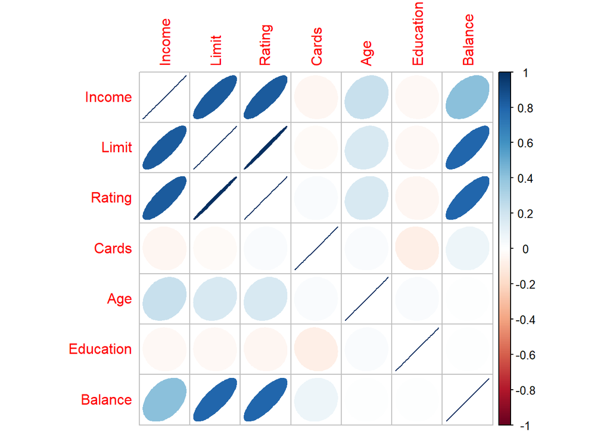

```r
library(corrplot)
df %>%
  dplyr::select(., Income, Limit, Rating, Cards, Age, Education, Balance) %>%
  cor(.) %>%
  corrplot(.,method="ellipse")
```

```r
library(GGally)
```

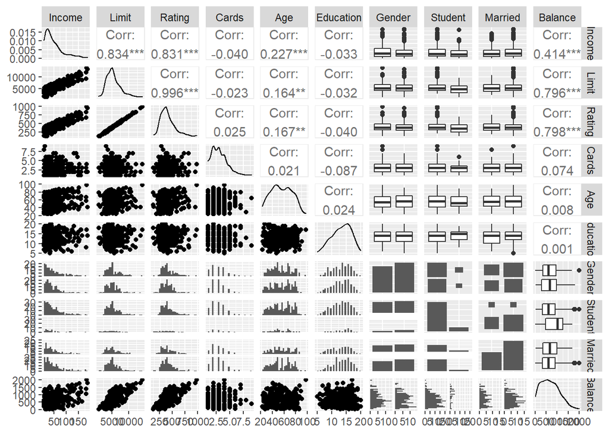

```r
df %>% filter(.,Balance > 0) -> d
ggpairs(d, progress = F)
```